# Data Science Technical Assessment

Adanna

2022-06-19

##The Process

The goal of this assessment is to discover which industry has the highest rate of fake job postings and graphically represent that.

In order to discover the industry with the highest rate of fame job postings, I had to study the given dataset.

I discovered that the fake job postings had a value of “1” in the fraudulent column.

I also filtered the dataset to find missing values and replaced all missing values with NA which means “Not available” to ensure there are no empty cells.

To install the packages needed, I ran the code below

install.packages(“tidyverse”) install.packages(“ggplot2”)

```r
library(tidyverse)
```

```r
library(ggplot2)
```

Storing the csv file as a data frame, I ran the following:

```r
job_postings <- read_csv("fake_job_postings.csv")
```

In order to view the column names, I ran:

```r
colnames(job_postings)
```

```
##  [1] "job_id"              "title"               "location"
##  [4] "department"          "salary_range"        "company_profile"
##  [7] "description"         "requirements"        "benefits"
## [10] "telecommuting"       "has_company_logo"    "has_questions"
## [13] "employment_type"     "required_experience" "required_education"
## [16] "industry"            "function"            "fraudulent"
```

Since fraudulent postings have a fraudulent value of “1”, I filtered the dataset to show only postings with a fraudulent value of “1” and saved it in a separate dataframe.

```r
fraudulent_posting <- filter(job_postings, fraudulent==1)
```

In order to show the industries with the highest occurrence of fraudulent postings, I plotted a bar chart of all the industries in the separate data frame of only fraudulent postings

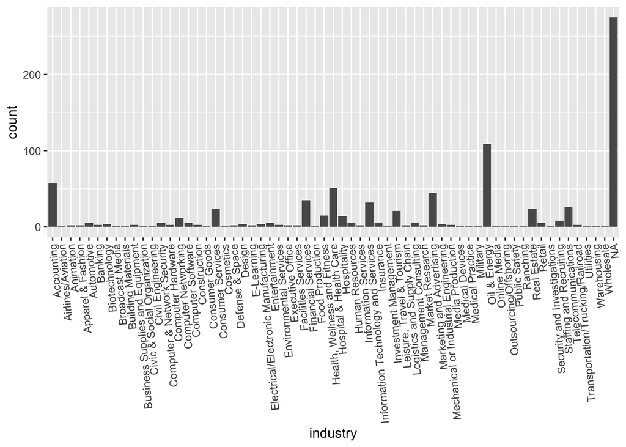

```r
ggplot(data = fraudulent_posting) + geom_bar(mapping = aes(x = industry)) +theme(axis.text.x= element_text(angle=95,vjust=0.5,hjust=1))
```

According to the bar chart generated, I discovered that most fake job postings do not state an industry and the fake job postings that do state an industry are mostly from the **Oil & Energy industry.**